# Statistical data visualizations (static)

# seaborn for statistical visualization

## seaborn

Using **pandas**, we see basic encodings, basically just `x` and `y`

**seaborn** gets us a richer set of visual encodings, using relatively straightforward code.

We'll see later how we'd do a similar plot using more granular code from **matplotlib**

## seaborn

The main classes of figures created using **seaborn**:

[figure not shown]

## seaborn

**seaborn** allows us to make it easier to create

- *facets*, i.e., subplots based on unique values of column(s) of the `DataFrame`
- *overlays*, i.e., plots where we can encode unique values of column(s) of a `DataFrame` on the same plot

## seaborn

**seaborn** code follows a general paradigm, where we

- start with a `DataFrame`
- specify the column(s) we want to plot
- specify the column(s) we want to either facet or overlay
- specify the encodings for the different data elements

```python
sns.set_style('white', {'font.family':'Futura'})
```

## Histograms

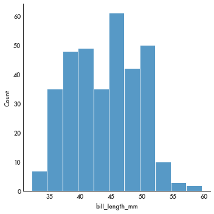

```python
sns.displot(
    data = penguins,     # DataFrame
    x = 'bill_length_mm',# columns to encode
    kind = 'hist'        # Type of encoding
    );
```

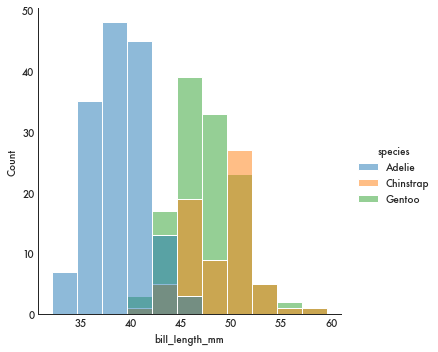

```python
sns.displot(
    data = penguins,     # DataFrame
    x = 'bill_length_mm',# columns to encode
    kind = 'hist',       # Type of encoding
    hue = 'species'      # Encode species as colors (hue) and overlay
    );
```

## Histograms

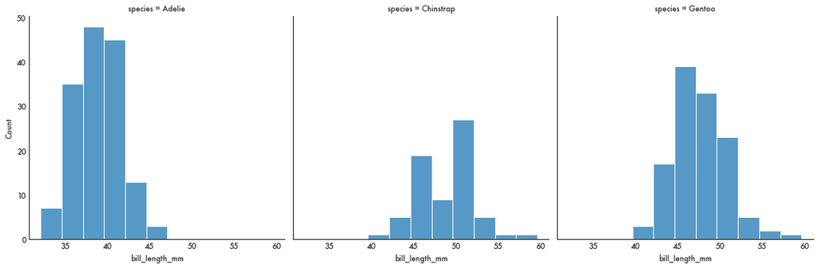

```python
sns.displot(
    data = penguins,     # DataFrame
    x = 'bill_length_mm',# columns to encode
    kind = 'hist',       # Type of encoding
    col = 'species'      # Encode species as facets, one per column
    );
```

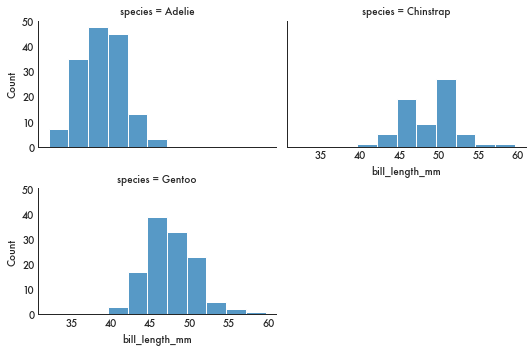

```python
sns.displot(
    data = penguins,     # DataFrame
    x = 'bill_length_mm',# columns to encodeS
    kind = 'hist',       # Type of encoding
    col = 'species',     # Encode species as facets, one per row
    col_wrap=2,
    height=2.5, aspect=1.5,
);
```

## Density plot

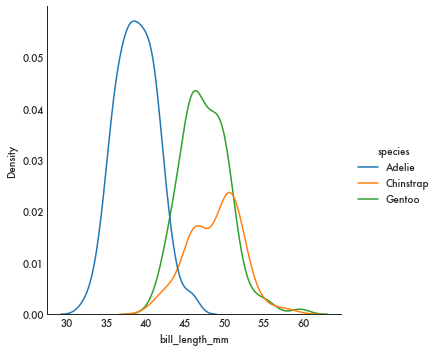

```python
sns.displot(data = penguins, x = 'bill_length_mm', hue = 'species', kind='kde');
```

## Empirical cumulative distribution plots

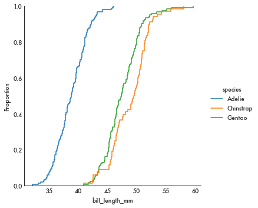

```python
sns.displot(data = penguins, x = 'bill_length_mm', hue = 'species', kind='ecdf');
plt.show()
```